# LAB GEEs

Author

A.Teixeira-Pinto & J. Harezlak

# Examples in the slides

Required libraries for different parts of the analysis.

```r
library(tidyverse)
library(gtsummary)   #for tables
library(tidyr)       #for the function pivot_longer and pivot_wider
library(ggplot2)     #for plots
library(geepack)     #for GEE with teh geeglm() function
library(gee)         #another library for gee
library(lme4)        #random effects
```

## Read and prepare the data

**Dataset**: `crp2.csv`

**Description**: 120 patients admitted to intensive care (ICU) with sepsis. C-reactive protein (CRP) is a marker of inflammation and, potentially, a marker of sepsis resolution. CRP was measured over 6 days (`crp1`,…`crp6`) or until discharge/death (`discharge_r`).

**Other variables**:

- SAPS - severity score measured within the first 24h in the ICU
- age - age at admission
- SEX - Male / Female
- SEPSIS - category of sepsis (Sepsis/Severe Sepsis/Septic Shock)
- antib_1h - was antibiotherapy administer within the first hour in ICU (No/Yes)

Let’s load the data and create a summary table

```r
#Read the data from a shared dropbox folder
  crp.Data.wide <- read.csv("https://www.dropbox.com/scl/fi/c5r8asu1o40ij7blxxwkq/crp2.csv?rlkey=cmxluw3gqo14mgkrhf6ta4cet&dl=1")

#Table summarizing the data
  head(crp.Data.wide)
```

```
    ID age SAPS crp1 crp2 crp3 crp4 crp5 crp6 antib_1h discharge        SEPSIS
1 1467  57   41  1.7 21.0 21.0   NA   NA  9.2       No     Alive Severe Sepsis
2 4098  38   28  1.8 12.9 14.2  7.4  4.0  2.8       No     Alive Severe Sepsis
3 4022  43   24  1.9  7.8  9.9  9.5 11.1  6.4      Yes     Alive        Sepsis
4  699  59   65  1.9  1.5  1.1  1.4  1.6   NA       No      Dead  Septic Shock
5 2865  68   45  1.9  1.3 14.1  7.6  6.9   NA      Yes     Alive Severe Sepsis
6  663  70   45  2.0  7.2  4.3  3.0  1.8  2.8       No     Alive Severe Sepsis
   SEX
1 Male
2 Male
3 Male
4 Male
5 Male
6 Male
```

```r
  tbl_summary(crp.Data.wide)
```

| **Characteristic** | **N = 120**<sup>1</sup> |
| --- | --- |
| ID | 2,815 (1,521, 3,877) |
| age | 65 (49, 76) |
| SAPS | 49 (37, 62) |
| Unknown | 2 |
| crp1 | 12 (5, 17) |
| crp2 | 13 (9, 21) |
| Unknown | 12 |
| crp3 | 14 (8, 23) |
| Unknown | 17 |
| crp4 | 11 (7, 20) |
| Unknown | 22 |
| crp5 | 8 (5, 18) |
| Unknown | 29 |
| crp6 | 8 (3, 12) |
| Unknown | 34 |
| antib_1h | 66 (55%) |
| discharge |  |
| Alive | 91 (76%) |
| Dead | 29 (24%) |
| SEPSIS |  |
| Sepsis | 13 (11%) |
| Septic Shock | 60 (50%) |
| Severe Sepsis | 47 (39%) |
| SEX |  |
| Female | 42 (35%) |
| Male | 78 (65%) |

<sup>1</sup> Median (Q1, Q3); n (%)

Changing the data structure wide to long

```r
crp.Data <- pivot_longer(data = crp.Data.wide,
                         cols = c(crp1, crp2, crp3, crp4, crp5, crp6), #cols = crp1:crp6
                         names_to = "day",
                         names_transform = list(day = as.numeric), #day as number
                         values_to = "crp",
                         names_prefix = "crp",
                         values_drop_na=TRUE)
head(crp.Data)
```

```
# A tibble: 6 × 9
     ID   age  SAPS antib_1h discharge SEPSIS        SEX     day   crp
  <int> <int> <int> <chr>    <chr>     <chr>         <chr> <dbl> <dbl>
1  1467    57    41 No       Alive     Severe Sepsis Male      1   1.7
2  1467    57    41 No       Alive     Severe Sepsis Male      2  21
3  1467    57    41 No       Alive     Severe Sepsis Male      3  21
4  1467    57    41 No       Alive     Severe Sepsis Male      6   9.2
5  4098    38    28 No       Alive     Severe Sepsis Male      1   1.8
6  4098    38    28 No       Alive     Severe Sepsis Male      2  12.9
```

Transfort CRP to logCRP to make the distribution closer to the normal distribution

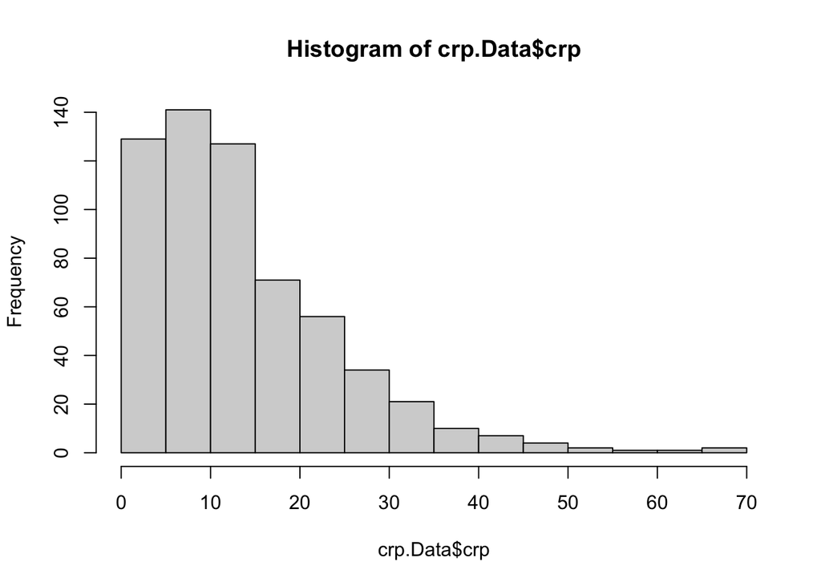

```r
#log transform CRP
  crp.Data$logcrp <- log(crp.Data$crp)

  hist(crp.Data$crp)
```

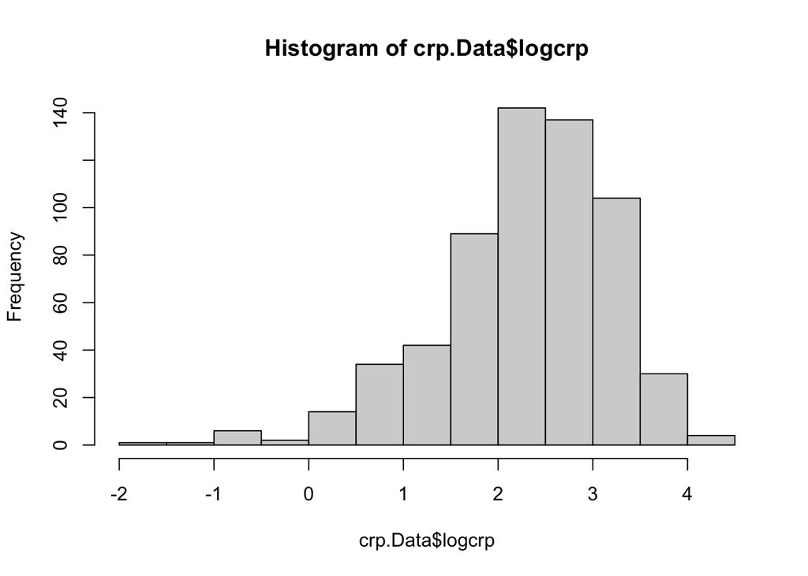

```r
  hist(crp.Data$logcrp)
```

## Spaghetti plot

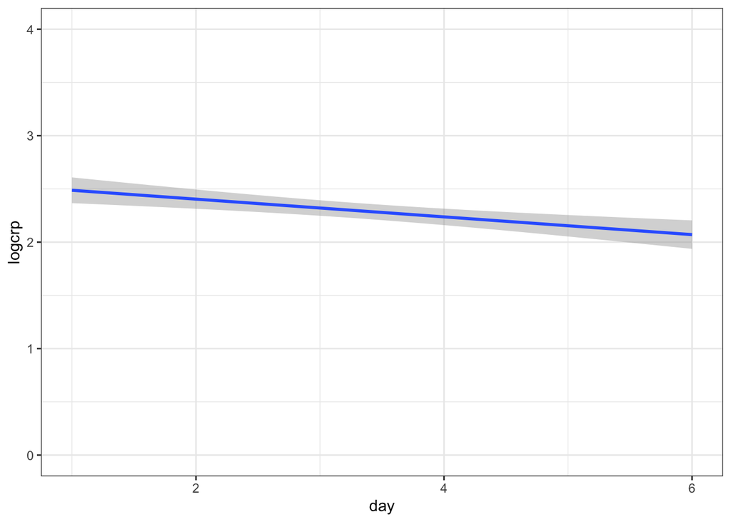

```r
#Basic spaghetti plot with linear trend
  ggplot(data = crp.Data,
         aes(x=day, y=logcrp, group=ID)) +
    #geom_line(alpha=.1) +
    geom_smooth(method=lm,  aes(group="none")) +
    coord_cartesian(ylim = c(0,4)) +                 #Better use this to change
    theme_bw()                                       #the scale
```

## Fiting the linar model with GEE

#### Fit a linear model with GEE using an INDEPENDENCE correlation structure

```r
gee.ind <- geeglm(logcrp ~ day,
                  id=ID,
                  corstr = "independence",
                  data=crp.Data)
summary(gee.ind)
```

```
Call:
geeglm(formula = logcrp ~ day, data = crp.Data, id = ID, corstr = "independence")

 Coefficients:
            Estimate  Std.err   Wald Pr(>|W|)
(Intercept)  2.57066  0.08229 975.79  < 2e-16 ***
day         -0.08333  0.02341  12.67 0.000371 ***
---
Signif. codes:  0 '***' 0.001 '**' 0.01 '*' 0.05 '.' 0.1 ' ' 1

Correlation structure = independence
Estimated Scale Parameters:

            Estimate Std.err
(Intercept)   0.8066  0.1025
Number of clusters:   120  Maximum cluster size: 6
```

Comparing the GEE Independence with a linear model that assumes independence

```r
summary(lm(logcrp ~ day,    #linear model
data=crp.Data))
```

```
Call:
lm(formula = logcrp ~ day, data = crp.Data)

Residuals:
   Min     1Q Median     3Q    Max
-3.680 -0.462  0.109  0.630  1.801

Coefficients:
            Estimate Std. Error t value Pr(>|t|)
(Intercept)   2.5707     0.0798   32.21  < 2e-16 ***
day          -0.0833     0.0214   -3.89  0.00011 ***
---
Signif. codes:  0 '***' 0.001 '**' 0.01 '*' 0.05 '.' 0.1 ' ' 1

Residual standard error: 0.9 on 604 degrees of freedom
Multiple R-squared:  0.0245,    Adjusted R-squared:  0.0228
F-statistic: 15.1 on 1 and 604 DF,  p-value: 0.000111
```

#### Fit a linear model with GEE using an EXCHANGEABLE correlation structure

```r
gee.exch <- geeglm(logcrp ~ day,
                  id=ID,
                  corstr = "exchangeable",
                  data=crp.Data)
summary(gee.exch)
```

```
Call:
geeglm(formula = logcrp ~ day, data = crp.Data, id = ID, corstr = "exchangeable")

 Coefficients:
            Estimate Std.err   Wald Pr(>|W|)
(Intercept)   2.5832  0.0792 1064.4  < 2e-16 ***
day          -0.0893  0.0221   16.2  5.6e-05 ***
---
Signif. codes:  0 '***' 0.001 '**' 0.01 '*' 0.05 '.' 0.1 ' ' 1

Correlation structure = exchangeable
Estimated Scale Parameters:

            Estimate Std.err
(Intercept)    0.807   0.102
  Link = identity

Estimated Correlation Parameters:
      Estimate Std.err
alpha    0.612   0.058
Number of clusters:   120  Maximum cluster size: 6
```

```r
tbl_regression(gee.exch)
```

| **Characteristic** | **Beta** | **95% CI**<sup>1</sup> | **p-value** |
| --- | --- | --- | --- |
| day | -0.09 | -0.13, -0.05 | <0.001 |

<sup>1</sup> CI = Confidence Interval

Comparing the GEE exchangeable with a linear random intercept model

```r
reffect <- lmer(logcrp ~ day + (1 | ID),
                 data=crp.Data)
summary (reffect)
```

```
Linear mixed model fit by REML ['lmerMod']
Formula: logcrp ~ day + (1 | ID)
   Data: crp.Data

REML criterion at convergence: 1292

Scaled residuals:
   Min     1Q Median     3Q    Max
-3.598 -0.475  0.073  0.597  2.764

Random effects:
 Groups   Name        Variance Std.Dev.
 ID       (Intercept) 0.480    0.693
 Residual             0.321    0.566
Number of obs: 606, groups:  ID, 120

Fixed effects:
            Estimate Std. Error t value
(Intercept)   2.5832     0.0810   31.89
day          -0.0892     0.0139   -6.43

Correlation of Fixed Effects:
    (Intr)
day -0.548
```

Plotting the predicted values from the random intercept model with the GEE model

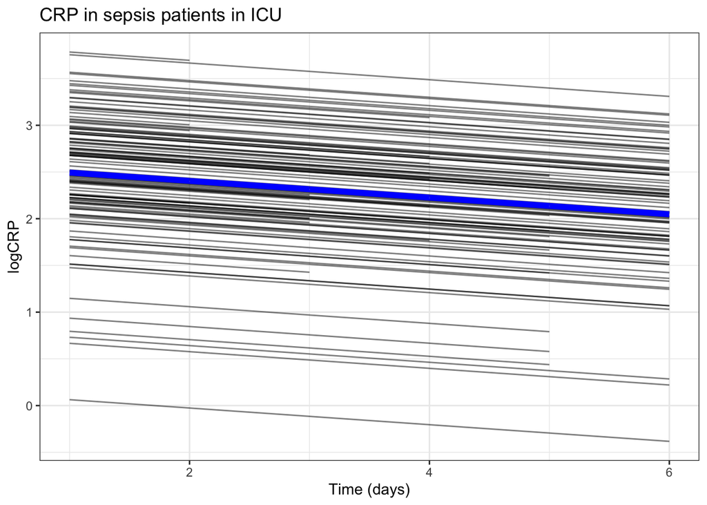

```r
ggplot(crp.Data, aes(x=day, y = predict(reffect), group=ID)) +
  geom_line(alpha=.5) +
  labs(title="CRP in sepsis patients in ICU",
       x = "Time (days)",
       y = "logCRP") +
  theme_bw() +
  geom_line(aes(y=predict(gee.exch), group="none"),
          color="blue", lwd=2)
```

#### Fit a linear model with GEE using an AR1 correlation structure

```r
gee.ar1 <- geeglm(logcrp ~ day,
                   id=ID,
                   corstr = "ar1",
                   data=crp.Data)
summary(gee.ar1)
```

```
Call:
geeglm(formula = logcrp ~ day, data = crp.Data, id = ID, corstr = "ar1")

 Coefficients:
            Estimate Std.err   Wald Pr(>|W|)
(Intercept)   2.4141  0.0858 791.66   <2e-16 ***
day          -0.0654  0.0223   8.61   0.0033 **
---
Signif. codes:  0 '***' 0.001 '**' 0.01 '*' 0.05 '.' 0.1 ' ' 1

Correlation structure = ar1
Estimated Scale Parameters:

            Estimate Std.err
(Intercept)    0.817   0.102
  Link = identity

Estimated Correlation Parameters:
      Estimate Std.err
alpha    0.791  0.0375
Number of clusters:   120  Maximum cluster size: 6
```

#### Fit a linear model with GEE using an UNSTRUCTURED correlation structure

```r
gee.unst <- geeglm(logcrp ~ day,
                  id=ID,
                  corstr = "unstructured",
                  data=crp.Data)
summary(gee.unst)
```

```
Call:
geeglm(formula = logcrp ~ day, data = crp.Data, id = ID, corstr = "unstructured")

 Coefficients:
            Estimate Std.err  Wald Pr(>|W|)
(Intercept)   1.9163  0.1071 320.4  < 2e-16 ***
day           0.2011  0.0417  23.3  1.4e-06 ***
---
Signif. codes:  0 '***' 0.001 '**' 0.01 '*' 0.05 '.' 0.1 ' ' 1

Correlation structure = unstructured
Estimated Scale Parameters:

            Estimate Std.err
(Intercept)     1.13    0.13
  Link = identity

Estimated Correlation Parameters:
          Estimate Std.err
alpha.1:2   0.3821  0.0579
alpha.1:3   0.2232  0.0531
alpha.1:4   0.2096  0.0834
alpha.1:5   0.1411  0.1447
alpha.1:6  -0.0298  0.2312
alpha.2:3   0.4475  0.0676
alpha.2:4   0.4254  0.0954
alpha.2:5   0.2587  0.1244
alpha.2:6   0.0227  0.2079
alpha.3:4   0.6457  0.0822
alpha.3:5   0.5257  0.1169
alpha.3:6   0.3499  0.1982
alpha.4:5   1.0214  0.1065
alpha.4:6   0.9586  0.1798
alpha.5:6   1.6682  0.1854
Number of clusters:   120  Maximum cluster size: 6
```

### Compare all the different fitted models

```r
#Coefficients
  tbl_stack(list(tbl_regression(gee.ind),
                 tbl_regression(gee.exch),
                 tbl_regression(gee.ar1),
                 tbl_regression(gee.unst)),
            group_header = c("**Independence**",
                             "**Exchangeable**",
                             "**AR1**",
                             "**Unstructured**"))
```

| **Characteristic** | **Beta** | **95% CI**<sup>1</sup> | **p-value** |
| --- | --- | --- | --- |
| **Independence** |  |  |  |
| day | -0.08 | -0.13, -0.04 | <0.001 |
| **Exchangeable** |  |  |  |
| day | -0.09 | -0.13, -0.05 | <0.001 |
| **AR1** |  |  |  |
| day | -0.07 | -0.11, -0.02 | 0.003 |
| **Unstructured** |  |  |  |
| day | 0.20 | 0.12, 0.28 | <0.001 |

<sup>1</sup> CI = Confidence Interval

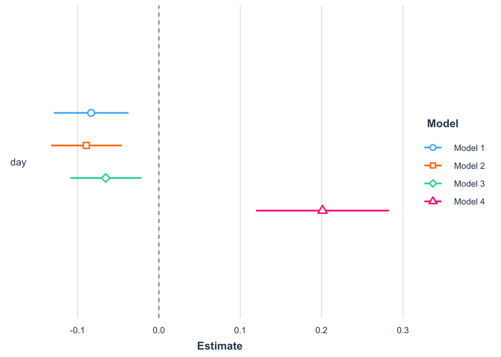

```r
#nice display of the coefficients
  jtools::plot_coefs(gee.ind, gee.exch, gee.ar1, gee.unst)
```

```r
#Compare the fitting
  QIC(gee.ind, gee.exch, gee.ar1, gee.unst)
```

```
         QIC QICu Quasi Lik  CIC params QICC
gee.ind  499  493      -244 4.91      2  499
gee.exch 498  493      -244 4.59      2  498
gee.ar1  504  499      -248 4.53      2  504
gee.unst 700  686      -341 8.88      2  706
```

# Exercises

## Dataset

**Dataset**: HIVmetabolites.csv

**Description**: Neurocognitive decline of chronically infected HIV.

**Variables**: - patid - patient id

- sexbin - male == 1
- racebin - white == 1
- educbin - educ>12 == 1
- age - age in years
- cd4val - cd4 count at enrollment
- nadircd4 - lifetime nadir CD4 count
- durationHIV - duration of HIV infection (years)
- HAART_years - years on HAART
- cpescore - CNS meds penetration score
- placopy.val - copy number of HIV RNA
- ADCstage.fac2b - impairment status (impaired == 1)
- GDS - Global Deficit Score
- t - years since enrollment (continuous)
- time.cat - years since enrollment (categorical)
- abs_* - absolute metabolite levels in 3 brain regions
- rel_* - relative (to Cr) metabolite levels in 3 brain regions
- rel_mid2 - Mid-frontal Cho/Cr ratio

```r
hiv.met <- read.csv("https://www.dropbox.com/scl/fi/1sra63885g2rudu8locj6/HIVmetabolites.csv?rlkey=wutk5tddu1qdzn0nx0j571ylv&st=3gj0bu3u&dl=1")
head(hiv.met)
```

## Questions

##### 1 - Plot the longitudinal profiles for the metabolite rel_mid2 and evaluate the trend over time

```r
  ggplot(     , aes(x=. , y=    , group=      )) +
    geom_line(alpha=      ) +
    geom_smooth(aes(group=      ))

  gee1 <- geeglm( ,
                 data=hiv.met ,
                 id= ,
                 corstr="      ")
  summary(gee1)
```

```r
   ggplot(hiv.met, aes(x=t, y=rel_mid2, group=patid)) +
    geom_line(alpha=.2) +
    geom_smooth(aes(group="none"))

     gee1 <- geeglm(rel_mid2 ~ t ,
                 data=hiv.met ,
                 id=patid,
                 corstr="exchangeable")
  summary(gee1)
```

##### 2 - Repeat the plot in (#1) but use facet to evaluate the longitudinal profile for males and females separate (variable sexbin). Is there evidence of a different trend?

```r
ggplot(     , aes(x=      , y=    , group=      )) +
  geom_line(alpha=      ) +
  geom_smooth(aes(group=      ))

gee1 <- geeglm(        ,
               data=hiv.met ,
               id= ,
               corstr="      ") +
  facet_grid(cols=vars(        ))

summary(gee1)
```

```r
  ggplot(hiv.met, aes(x=t, y=rel_mid2, group=patid, color=factor(patid))) +
    geom_line(alpha=.2, show.legend = F) +
    geom_smooth(aes(group="none"), show.legend = F)+
    facet_grid(cols=vars(sexbin))

  gee2 <- geeglm(rel_mid2 ~ t*sexbin ,
                 data=hiv.met ,
                 id=patid,
                 corstr="exchangeable")
  summary(gee2)
```

##### 3 - Repeat the analysis of (#2) but instead of sexbin use for the level of CD4 at enrollment, variable nadircd4.cat (low vs Med). Is there evidence of a different trend?

```r
ggplot(     , aes(x=      , y=    , group=      )) +
  geom_line(alpha=      ) +
  geom_smooth(aes(group=      ))  +
  facet_grid(cols=vars(       ))

  gee4 <- geeglm(                  ,
                 data=hiv.met ,
                 id=          ,
                 corstr="           ")
  summary(gee4)
```

```r
  ggplot(hiv.met, aes(x=t, y=rel_mid2, group=patid)) +
    geom_line(alpha=.2) +
    geom_smooth(aes(group="none")) +
    facet_grid(cols=vars(nadircd4.cat))

  gee4 <- geeglm(rel_mid2 ~ t*nadircd4.cat,
                 data=hiv.met ,
                 id=patid,
                 corstr="exchangeable")
  summary(gee4)
```

##### 4 - Plot the fitted line from the linear model used in (#3) together with the individual longitudinal profiles, separated by nadircd4.cat levels

```r
  pred.gee4 <- predict(    , hiv.met)

  ggplot(hiv.met, aes(x=t, y=rel_mid2, group=patid)) +
    geom_line(alpha=.2) +
    geom_line(aes(y=    , group="none")) +
    facet_grid(cols=vars(        ))
```

```r
  pred.gee4 <- predict(gee4, hiv.met)

  ggplot(hiv.met, aes(x=t, y=rel_mid2, group=patid)) +
    geom_line(alpha=.2) +
    geom_line(aes(y=pred.gee4, group="none")) +
    facet_grid(cols=vars(nadircd4.cat))
```

##### 5 - Fit a model for rel_mid2 using the covariates: t, nadircd4.cat, sexbin, age, HAART_years, educbin, racebin try different working correlation structures and compare the results

```r
  gee.ind<- geeglm(rel_mid2 ~ t*nadircd4.cat + t*sexbin + age +
                     HAART_years + educbin + racebin,
                   data=hiv.met ,
                   id=patid,
                   corstr="independence")

  gee.exch <-

  gee.ar1 <-

  gee.unst <-


  library(jtools)
  plot_coefs (      ,     ,       ,      )
```

```r
  gee.ind<- geeglm(rel_mid2 ~ t*nadircd4.cat + t*sexbin + age +
                     HAART_years + educbin + racebin,
                   data=hiv.met ,
                   id=patid,
                   corstr="independence")

  gee.exch <- geeglm(rel_mid2 ~ t*nadircd4.cat + t*sexbin + age +
                       HAART_years + educbin + racebin,
                 data=hiv.met ,
                 id=patid,
                 corstr="exchangeable")

  gee.ar1 <- geeglm(rel_mid2 ~ t*nadircd4.cat + t*sexbin + age +
                   HAART_years + educbin + racebin,
                 data=hiv.met ,
                 id=patid,
                 corstr="ar1")

  gee.unst <- geeglm(rel_mid2 ~ t*nadircd4.cat + t*sexbin + age +
                   HAART_years + educbin + racebin,
                 data=hiv.met ,
                 id=patid,
                 corstr="unstructured")


  library(jtools)
  plot_coefs (gee.ind, gee.exch, gee.ar1, gee.unst)
```

##### 6 - Fit a random intercept model for rel_mid2 using the covariates: t, nadircd4.cat, sexbin, age, HAART_years, educbin, racebin. Compare the results with a model fitted with GEE and exchangeablecorrelation matrix

```r
  re.model <- lmer(       )

  library(jtools)
  plot_coefs (          ,     )
```

```r
  re.model <- lmer(rel_mid2 ~ t*nadircd4.cat + t*sexbin + age +
                       HAART_years + educbin + racebin + (1|patid),
                     data=hiv.met)

  library(jtools)
  plot_coefs (re.model, gee.exch)
```